# SODA

Spanish Occupational Accidents Data Analysis

Luis Gentner

luis.quentin.gentner@estudiantat.upc.edu

UPC ESEIAAT

2023-05-30

## Outline

- Exploration of the work accident dataset
- Shiny app showcase
- Gathering of economic data
- Analyzing the relation of accidents and economic indicators

# Work Accident Dataset

## Used data

- Dataset from the Spanish [Ministry of Labour and Social Economy](https://www.mites.gob.es/estadisticas/eat/welcome.htm)
- Used Indicator: ATR-I-1.3, indicates the work accident number per 100,000 workers for a given year
  - By autonomous community (AC) and by economic sector
  - Data from 2009 to 2021
  - Took recalculated data for years 2009 to 2019

## Work accidents per year and sector

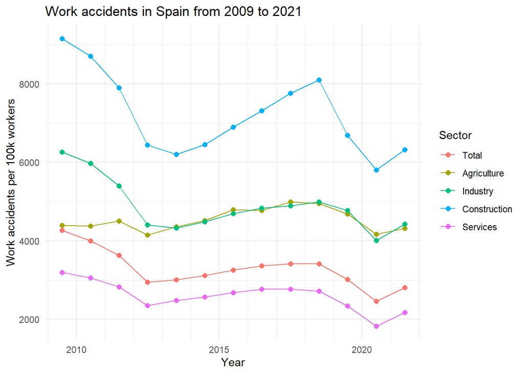

## Work accidents per AC

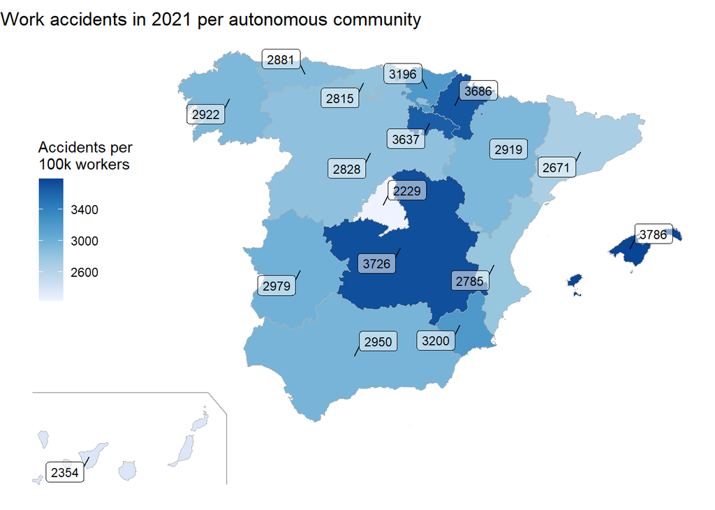

## Deriving the annual change rate

```r
atr <- atr |>
  mutate(acc_yoy = (accidents - lag(accidents)) / lag(accidents),
         .by = c(sector, ccaa))
```

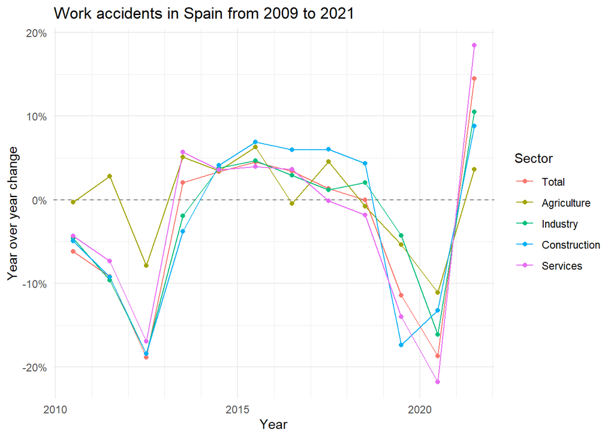

## Shiny app

- Interactive dashboard to show current trends, regional analysis and map
- Used packages:
  - [`{bslib}`](https://rstudio.github.io/bslib/): Modern UI components for Shiny, replaces shinydashboard
  - [`{thematic}`](https://rstudio.github.io/thematic/): ggplot2 auto-theming

[figure not shown]

- Try yourself: [luisgentner.shinyapps.io/SODA](https://luisgentner.shinyapps.io/SODA/)

# Comparison with Economic Data

## Gathered economic data

| Description | Per AC | Per sector |
| --- | --- | --- |
| Working population | ✓ | ✓ |
| Working population of sector, share | ✓ | ✓ |
| Non-EU workers, share | ✓ |  |
| Indexed GDP |  | ✓ |
| Indexed GDP, YoY change rate |  | ✓ |
| Inflation, consumer price index |  |  |
| Inflation, YoY change rate |  |  |

All indices were directly extracted or derived from [`ESdata`](https://github.com/jmsallan/ESdata).

## Selected plots: Relative working population

```r
wpop <- wpop |>
  mutate(wpop_rel = wpop / wpop[sector == "total"],
         .by = c(periodo, region))
```

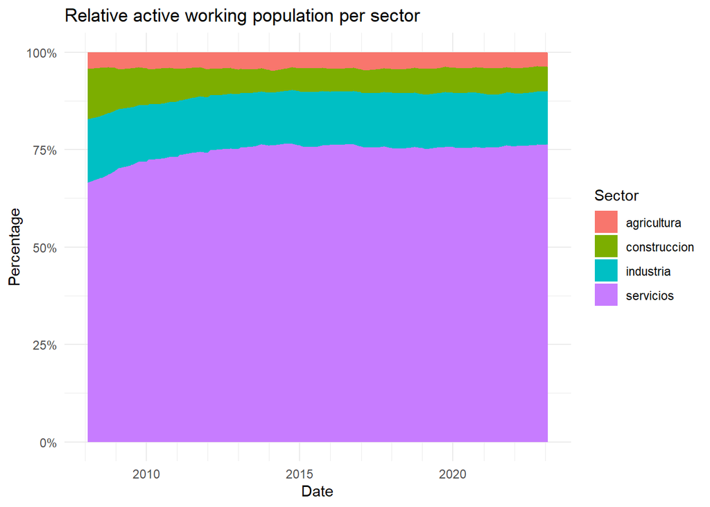

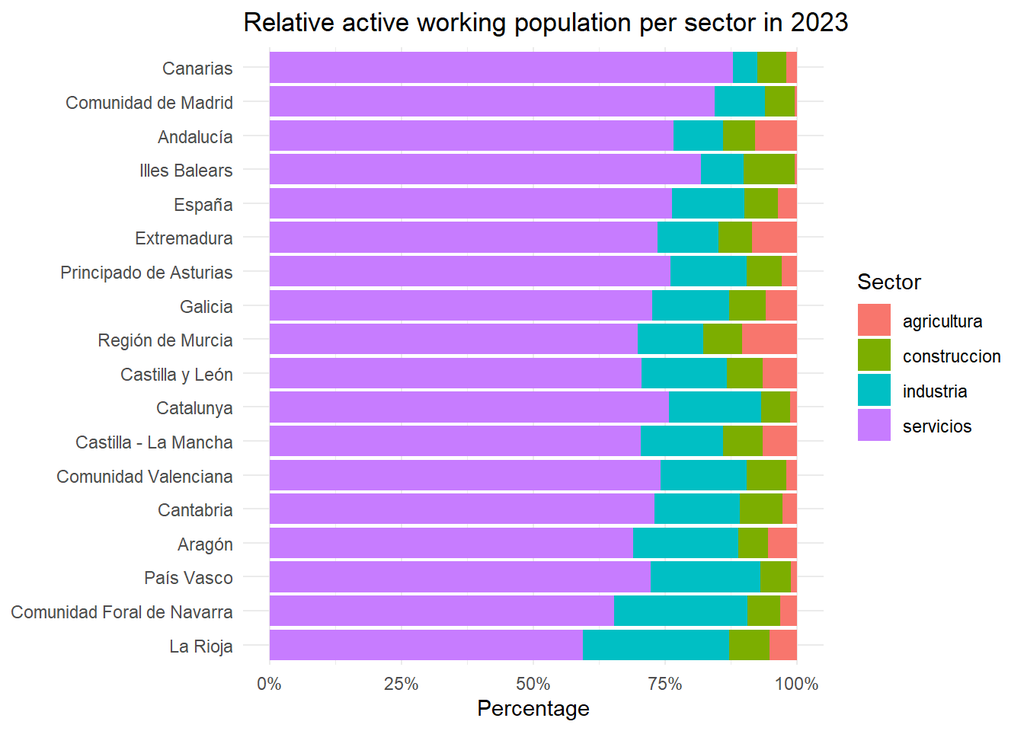

## Selected plots: GDP

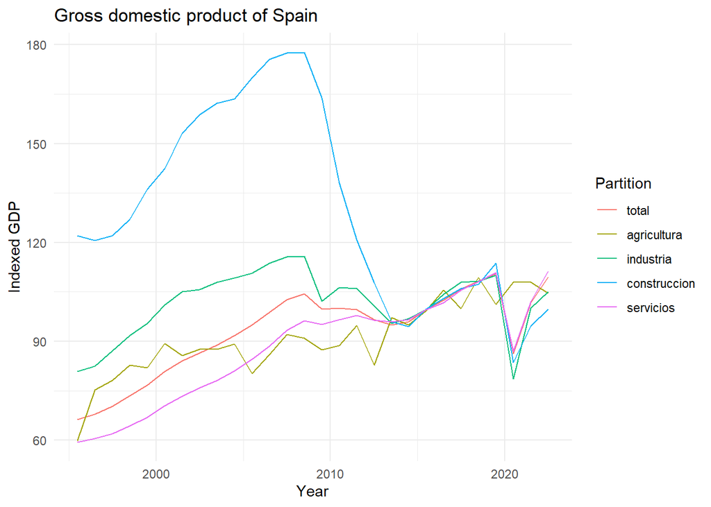

- Used adjusted value-added GDP (`pib_pm_oferta`)
- Available per economic sector
- Indexed values showed higher correlation with accidents than base values

## Relation analysis with ML

- Correlation analysis difficult due to groups
- Analyzing the variable importance of a random forest model instead
- Joined economic indices with accidents by sector and AC
  - For given data point of sector and AC, only economic data of this sector and/or AC is shown to the model
- Dummy encoding of AC and sector
- Used `initial_time_split` for train/test set splitting so the model can’t look into the future

## Model predictions

- Good prediction accuracy on test period

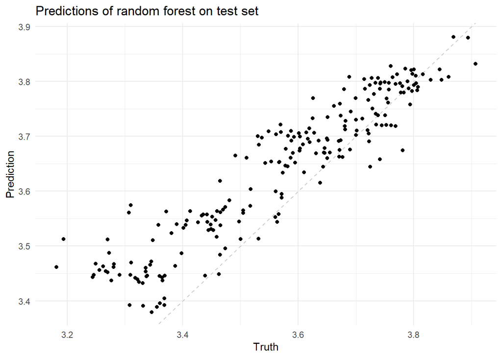

## Variable importance

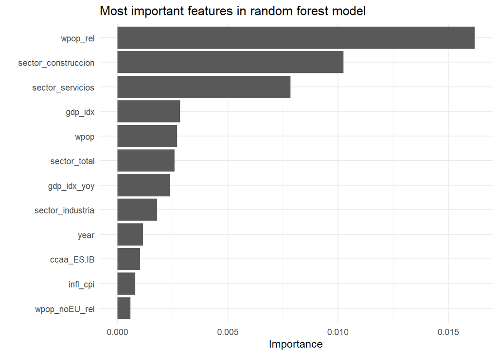

## Relation analysis outcomes

- Three most important features:
  - Relative working population in sector
  - Construction sector dummy
  - Service sector dummy
- GDP is more important than inflation (CPI)
- Work accidents on the Balearics are unlike other AC

## Thank you!

- GitHub: github.com/lqgentner/SODA
- Shiny app: [luisgentner.shinyapps.io/SODA](https://luisgentner.shinyapps.io/SODA/)

[figure not shown]

Luis Gentner | SODA | UPC ESEIAAT | Business Analytics 2023